# HOMEWORK 1

Sabina Sidarovich

## Data uploading

```r
bookings = read.csv2("hotel_bookings.csv", sep=',')
head(bookings)
```

```
##          hotel is_canceled lead_time arrival_date_year arrival_date_month
## 1 Resort Hotel           0       342              2015               July
## 2 Resort Hotel           0       737              2015               July
## 3 Resort Hotel           0         7              2015               July
## 4 Resort Hotel           0        13              2015               July
## 5 Resort Hotel           0        14              2015               July
## 6 Resort Hotel           0        14              2015               July
##   arrival_date_week_number arrival_date_day_of_month stays_in_weekend_nights
## 1                       27                         1                       0
## 2                       27                         1                       0
## 3                       27                         1                       0
## 4                       27                         1                       0
## 5                       27                         1                       0
## 6                       27                         1                       0
##   stays_in_week_nights adults children babies meal country market_segment
```

[output cut: 41 more lines]

## Data exploration and preprocessing

I should mention that I did some EDA for this homework in Python (as I thought it might be useful for the future), so my decisions are based on insights gained from the exploration.

```r
glimpse(bookings)
```

```
## Rows: 119,390
## Columns: 32
## $ hotel                          <chr> "Resort Hotel", "Resort Hotel", "Resort~
## $ is_canceled                    <int> 0, 0, 0, 0, 0, 0, 0, 0, 1, 1, 1, 0, 0, ~
## $ lead_time                      <int> 342, 737, 7, 13, 14, 14, 0, 9, 85, 75, ~
## $ arrival_date_year              <int> 2015, 2015, 2015, 2015, 2015, 2015, 201~
## $ arrival_date_month             <chr> "July", "July", "July", "July", "July",~
## $ arrival_date_week_number       <int> 27, 27, 27, 27, 27, 27, 27, 27, 27, 27,~
## $ arrival_date_day_of_month      <int> 1, 1, 1, 1, 1, 1, 1, 1, 1, 1, 1, 1, 1, ~
## $ stays_in_weekend_nights        <int> 0, 0, 0, 0, 0, 0, 0, 0, 0, 0, 0, 0, 0, ~
## $ stays_in_week_nights           <int> 0, 0, 1, 1, 2, 2, 2, 2, 3, 3, 4, 4, 4, ~
## $ adults                         <int> 2, 2, 1, 1, 2, 2, 2, 2, 2, 2, 2, 2, 2, ~
## $ children                       <int> 0, 0, 0, 0, 0, 0, 0, 0, 0, 0, 0, 0, 0, ~
## $ babies                         <int> 0, 0, 0, 0, 0, 0, 0, 0, 0, 0, 0, 0, 0, ~
## $ meal                           <chr> "BB", "BB", "BB", "BB", "BB", "BB", "BB~
```

[output cut: 19 more lines]

```r
summary(bookings)
```

```
##     hotel            is_canceled       lead_time   arrival_date_year
##  Length:119390      Min.   :0.0000   Min.   :  0   Min.   :2015
##  Class :character   1st Qu.:0.0000   1st Qu.: 18   1st Qu.:2016
##  Mode  :character   Median :0.0000   Median : 69   Median :2016
##                     Mean   :0.3704   Mean   :104   Mean   :2016
##                     3rd Qu.:1.0000   3rd Qu.:160   3rd Qu.:2017
##                     Max.   :1.0000   Max.   :737   Max.   :2017
##
##  arrival_date_month arrival_date_week_number arrival_date_day_of_month
##  Length:119390      Min.   : 1.00            Min.   : 1.0
##  Class :character   1st Qu.:16.00            1st Qu.: 8.0
##  Mode  :character   Median :28.00            Median :16.0
##                     Mean   :27.17            Mean   :15.8
##                     3rd Qu.:38.00            3rd Qu.:23.0
##                     Max.   :53.00            Max.   :31.0
##
##  stays_in_weekend_nights stays_in_week_nights     adults
##  Min.   : 0.0000         Min.   : 0.0         Min.   : 0.000
##  1st Qu.: 0.0000         1st Qu.: 1.0         1st Qu.: 2.000
##  Median : 1.0000         Median : 2.0         Median : 2.000
##  Mean   : 0.9276         Mean   : 2.5         Mean   : 1.856
##  3rd Qu.: 2.0000         3rd Qu.: 3.0         3rd Qu.: 2.000
##  Max.   :19.0000         Max.   :50.0         Max.   :55.000
##
##     children           babies              meal             country
##  Min.   : 0.0000   Min.   : 0.000000   Length:119390      Length:119390
##  1st Qu.: 0.0000   1st Qu.: 0.000000   Class :character   Class :character
##  Median : 0.0000   Median : 0.000000   Mode  :character   Mode  :character
##  Mean   : 0.1039   Mean   : 0.007949
##  3rd Qu.: 0.0000   3rd Qu.: 0.000000
##  Max.   :10.0000   Max.   :10.000000
##  NA's   :4
##  market_segment     distribution_channel is_repeated_guest
##  Length:119390      Length:119390        Min.   :0.00000
##  Class :character   Class :character     1st Qu.:0.00000
##  Mode  :character   Mode  :character     Median :0.00000
##                                          Mean   :0.03191
##                                          3rd Qu.:0.00000
##                                          Max.   :1.00000
##
```

[output cut: 25 more lines]

```
##  Min.   :0.00000             Min.   :0.0000            Length:119390
##  1st Qu.:0.00000             1st Qu.:0.0000            Class :character
##  Median :0.00000             Median :0.0000            Mode  :character
##  Mean   :0.06252             Mean   :0.5714
##  3rd Qu.:0.00000             3rd Qu.:1.0000
##  Max.   :8.00000             Max.   :5.0000
##
##  reservation_status_date
##  Length:119390
##  Class :character
##  Mode  :character
##
##
##
##
```

Removing the columns with the lowest correlation (below 0.05) or high percent of missing data (they were found during EDA in another notebook attached, if the explanation for the choice is needed) and replacing the missing values.

```r
bookings$children[which(is.na(bookings$children))] <- 0
bookings <- bookings[, !(names(bookings) %in% c('reservation_status_date', 'company', 'babies',
 'arrival_date_day_of_month',
 'days_in_waiting_list',
 'arrival_date_week_number',
 'agent'))]
bookings$country[which(is.na(bookings$country))] <- 'Other'
```

## Training the model

The dataframe was split using the caret package.

```r
set.seed(111)
index <- createDataPartition(bookings$is_canceled, p = 0.8, list = FALSE)
train <- bookings[index,]
test  <- bookings[-index,]
```

Training a random forest model, as Kaggle users got 95% accuracy when used this model on the dataframe.

```r
set.seed(11)
model <- ranger(is_canceled ~., data = train)
```

## Creation of an explainer

```r
explainer_rf <- DALEX::explain(model,
                               data = test[,-2],
                               y = test$is_canceled,
                               label='random_forest')
```

```
## Preparation of a new explainer is initiated
##   -> model label       :  random_forest
##   -> data              :  23878  rows  24  cols
##   -> target variable   :  23878  values
##   -> predict function  :  yhat.ranger  will be used (  default  )
##   -> predicted values  :  No value for predict function target column. (  default  )
##   -> model_info        :  package ranger , ver. 0.13.1 , task regression (  default  )
##   -> predicted values  :  numerical, min =  0 , mean =  0.3568926 , max =  0.9993156
##   -> residual function :  difference between y and yhat (  default  )
##   -> residuals         :  numerical, min =  -0.2690358 , mean =  0.009679095 , max =  0.448
##   A new explainer has been created!
```

## Observation No 1

Calculating the probability of the cancellation for one of the observations:

```r
prediction_a <-predict(model, data=test[8741, -2])
prediction_a$predictions
```

```
## [1] 0.6750667
```

### Break-Down plot

```r
breakdown_a <- predict_parts(explainer = explainer_rf,
                       new_observation = test[8741, ],
                       type = "break_down")
breakdown_a
```

```
##                                                   contribution
## random_forest: intercept                                 0.357
## random_forest: reservation_status = Check-Out            0.573
## random_forest: required_car_parking_spaces = 1          -0.207
## random_forest: country = FRA                            -0.003
## random_forest: arrival_date_year = 2015                 -0.005
## random_forest: customer_type = Contract                 -0.009
## random_forest: total_of_special_requests = 1            -0.024
## random_forest: deposit_type = No Deposit                -0.007
## random_forest: market_segment = Online TA                0.008
## random_forest: reserved_room_type = A                   -0.001
## random_forest: adr = 133                                 0.001
## random_forest: previous_cancellations = 0               -0.003
## random_forest: lead_time = 17                           -0.011
## random_forest: distribution_channel = TA/TO              0.001
## random_forest: arrival_date_month = September           -0.001
## random_forest: hotel = City Hotel                        0.003
## random_forest: booking_changes = 0                       0.003
## random_forest: stays_in_week_nights = 3                 -0.001
## random_forest: stays_in_weekend_nights = 1              -0.001
## random_forest: assigned_room_type = A                    0.004
## random_forest: children = 0                              0.000
## random_forest: previous_bookings_not_canceled = 0        0.000
## random_forest: meal = BB                                 0.000
## random_forest: is_repeated_guest = 0                     0.000
## random_forest: adults = 2                               -0.001
## random_forest: prediction                                0.675
```

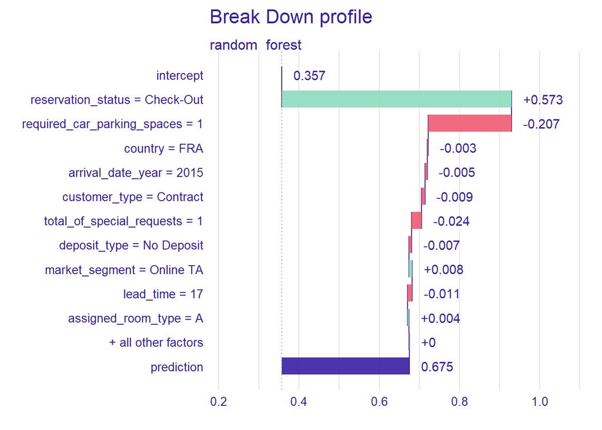

```r
plot(breakdown_a)
```

As can be seen, the reservation status has the biggest impact on the variable, which is quite natural. However, the interesting thing concerns the required_car_parking_spaces variable: we see that it has strong negative impact on the observation’s predicted value. The rest of the variables have almost no impact on the outcome.

### Shapley values

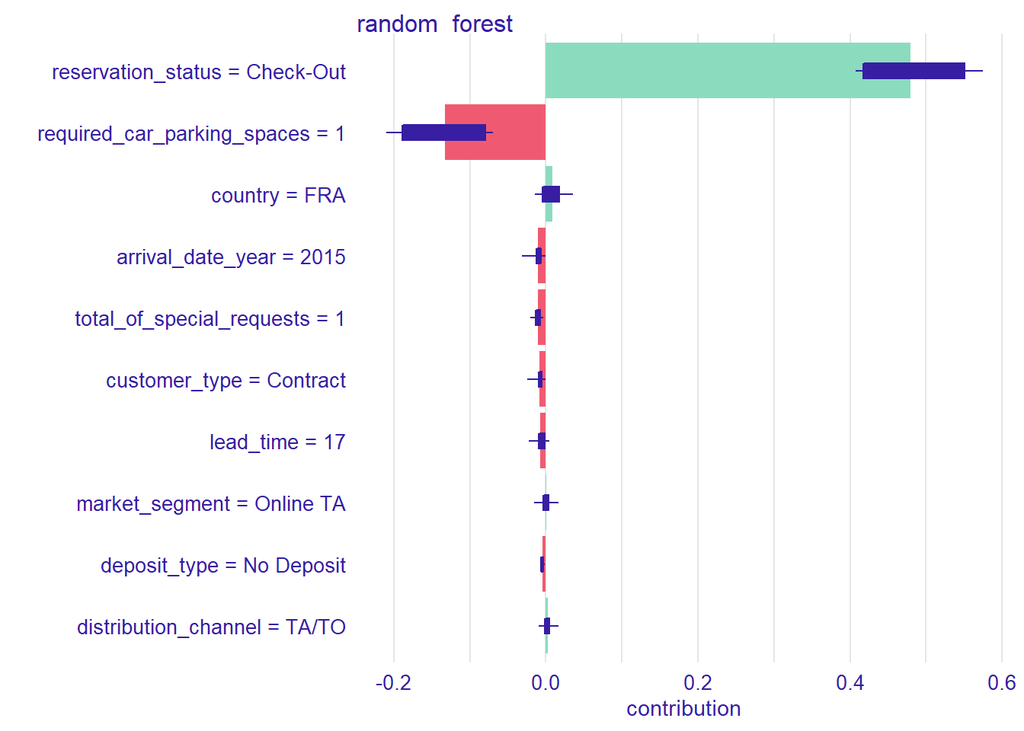

```r
shap_pr_a <- predict_parts(explainer = explainer_rf,
                         new_observation = test[8741, ],
                         type = "shap")
plot(shap_pr_a)
```

The results are quite similar; the only difference worth mentioning is the country value influence, as in this case it has positive influence.

## Observation No 2

```r
prediction_b <-predict(model, data=test[25, -2])
prediction_b$predictions
```

```
## [1] 0.8930424
```

### Break-Down plot

```r
breakdown_b <- predict_parts(explainer = explainer_rf,
                       new_observation = test[25, -2],
                       type = "break_down")
breakdown_b
```

```
##                                                   contribution
## random_forest: intercept                                 0.357
## random_forest: reservation_status = Check-Out            0.573
## random_forest: country = FRA                            -0.009
## random_forest: arrival_date_year = 2015                 -0.027
## random_forest: customer_type = Transient-Party          -0.016
## random_forest: total_of_special_requests = 2            -0.019
## random_forest: deposit_type = No Deposit                -0.005
## random_forest: market_segment = Online TA                0.000
## random_forest: reserved_room_type = A                   -0.003
## random_forest: adr = 73.8                               -0.002
## random_forest: previous_cancellations = 0               -0.002
## random_forest: lead_time = 100                           0.000
## random_forest: distribution_channel = TA/TO              0.021
## random_forest: arrival_date_month = July                 0.001
## random_forest: hotel = Resort Hotel                      0.003
## random_forest: booking_changes = 0                       0.001
## random_forest: required_car_parking_spaces = 0           0.012
## random_forest: stays_in_weekend_nights = 1               0.002
## random_forest: stays_in_week_nights = 1                  0.003
## random_forest: assigned_room_type = A                    0.000
## random_forest: children = 0                              0.000
## random_forest: previous_bookings_not_canceled = 0        0.000
## random_forest: meal = BB                                 0.001
## random_forest: is_repeated_guest = 0                     0.000
## random_forest: adults = 2                                0.000
## random_forest: prediction                                0.893
```

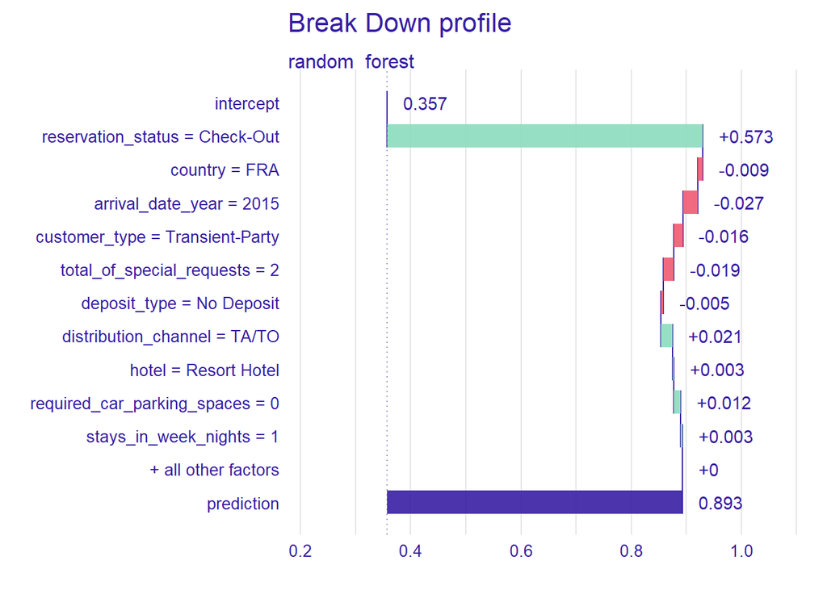

```r
plot(breakdown_b)
```

### Shapley values

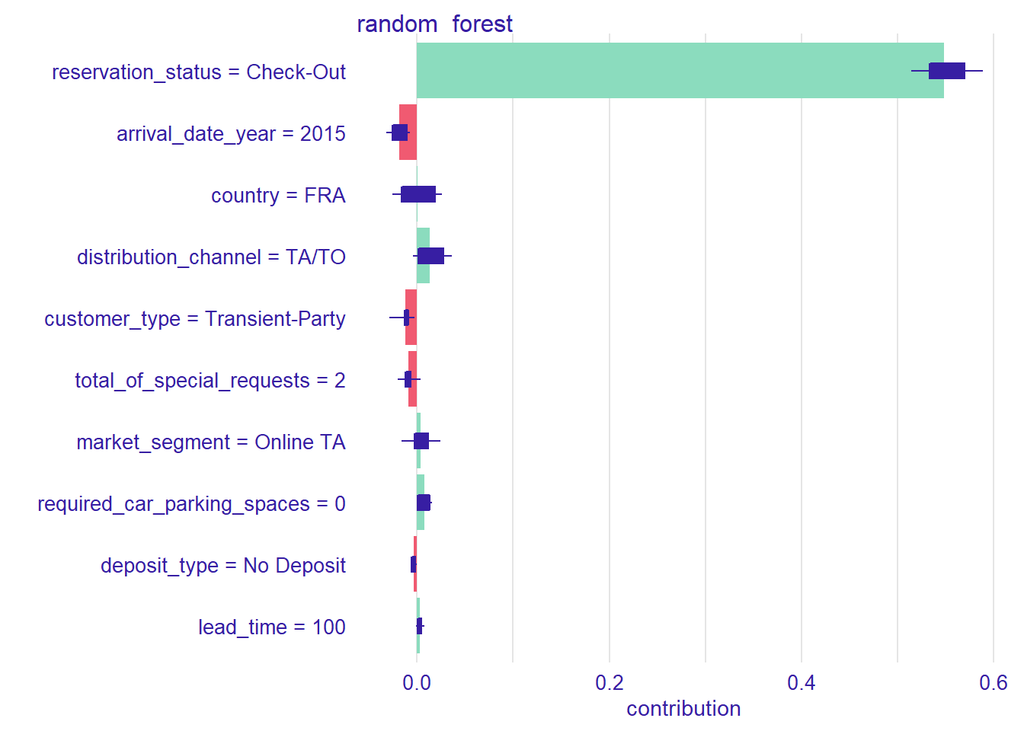

```r
shap_pr_b <- predict_parts(explainer = explainer_rf,
                         new_observation = test[25, ],
                         type = "shap")
plot(shap_pr_b)
```

Comparing shapley values, we see that country variable now has almost no impact, whereas in the first case it had positive impact.

P.S. I am sorry for sending this in late, but I spent the last 5 hours fighting with the dataset and trying to find some differences worth showing. I am not sure if the model is overfit of there’s some other reason for the fact that each observation I checked basically had the same coefficient for reservation_status and required_parking_spaces (maybe I’m just unlucky, although I tried choosing the variables with min and max probability and comparing them). My guess is that I should definitely work on the model, as the probability in most cases was quite high, despite the actual value being 0. The lesson from all that is that you shouldn’t always trust people on Kaggle.